# Consumo de Gasolina

Marco Ramirez, Estuardo Hernandez

2022-08-02

El dataset de consumo cuenta con 269 filas y 4 las cuales son las siguientes:

```r
str(consumo)
```

```
## tibble [269 x 4] (S3: tbl_df/tbl/data.frame)
##  $ Fecha             : Date[1:269], format: "2000-01-01" "2000-02-01" ...
##  $ Gasolina superior : num [1:269] 308157 307766 331910 315648 319668 ...
##  $ Gasolina regular  : num [1:269] 202645 205531 229500 210680 208164 ...
##  $ Diesel alto azufre: num [1:269] 634667 642381 699807 586804 656948 ...
```

## Resumen general del dataset

```r
summary(consumo)
```

```
##      Fecha            Gasolina superior Gasolina regular Diesel alto azufre
##  Min.   :2000-01-01   Min.   :300243    Min.   :160742   Min.   : 507663
##  1st Qu.:2005-08-01   1st Qu.:380800    1st Qu.:212696   1st Qu.: 688104
##  Median :2011-03-01   Median :411089    Median :268918   Median : 793694
##  Mean   :2011-03-02   Mean   :451432    Mean   :348337   Mean   : 837103
##  3rd Qu.:2016-10-01   3rd Qu.:545210    3rd Qu.:476278   3rd Qu.: 966104
##  Max.   :2022-05-01   Max.   :768103    Max.   :821882   Max.   :1417380
```

## Clasificación de variables

#### Fecha: Continua

#### Gasolina superior: Cuantitativa continua

#### Gasolina regular: Cuantitativa continua

#### Diesel alto azufre: Cuantitativa continua

## Representación gráfica de las variables

#### -Fecha

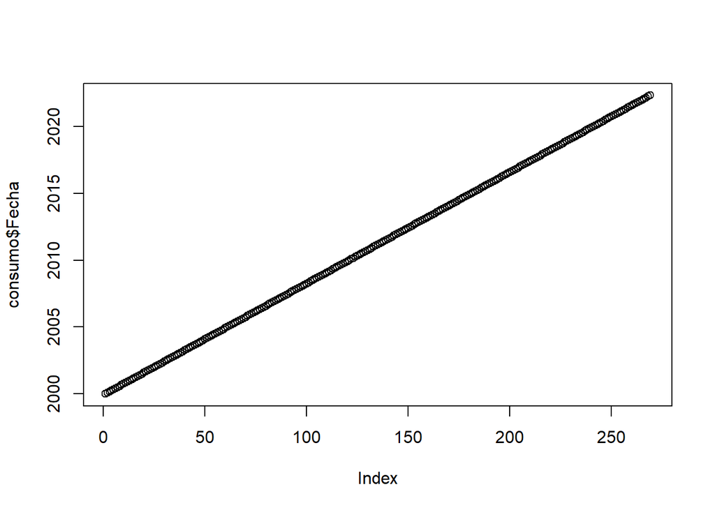

#### -Gasolina superior

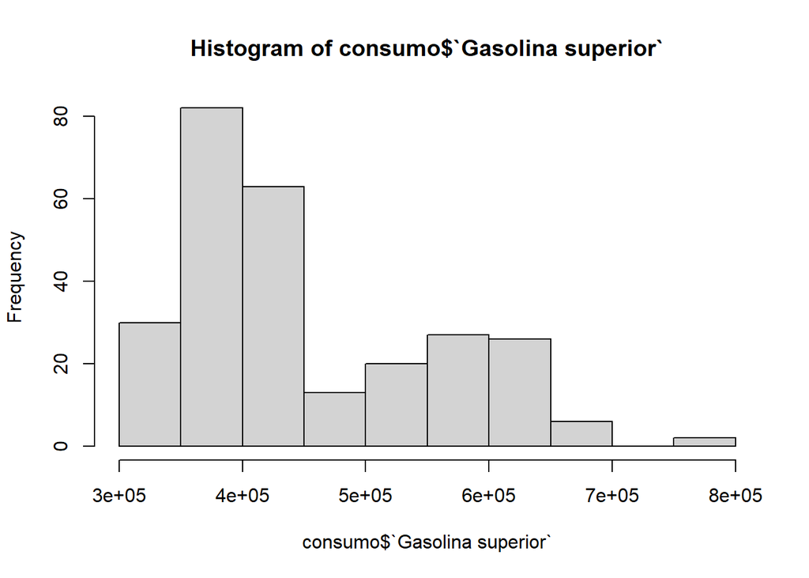

#### -Gasolina regular

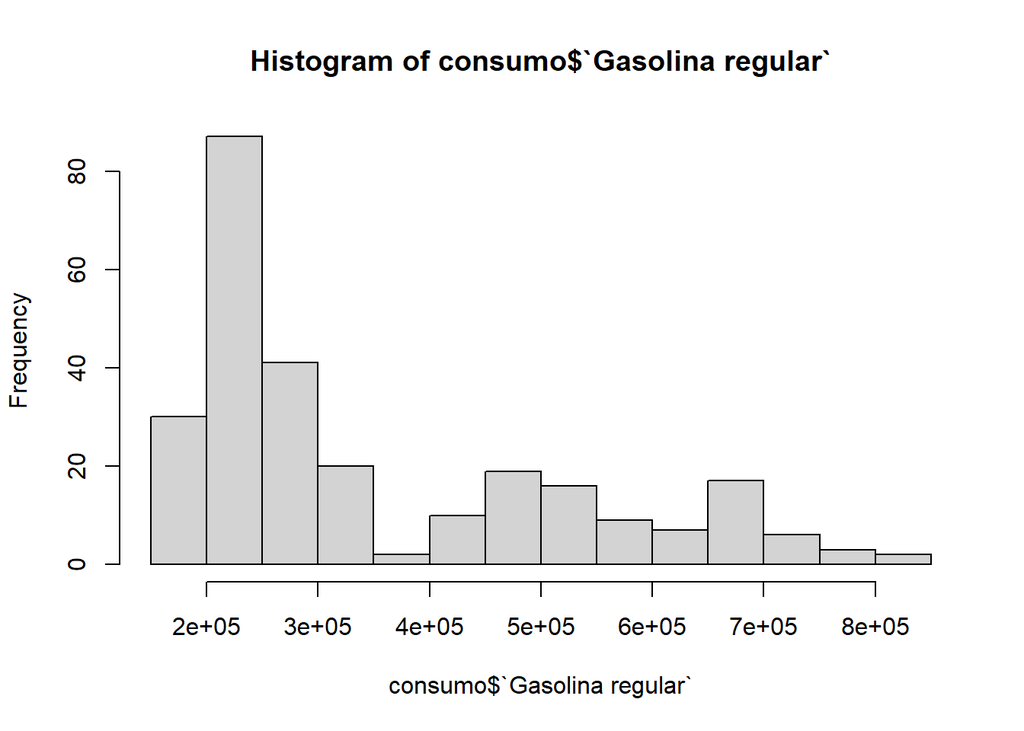

#### -Diesel

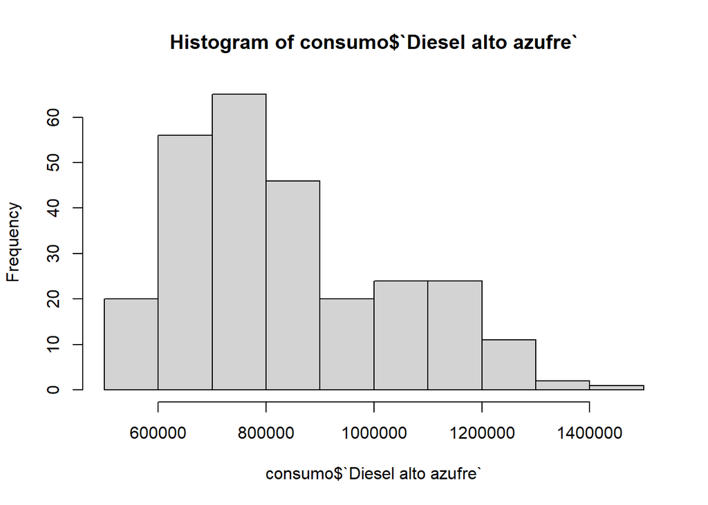

## Correlación de las variables numéricas

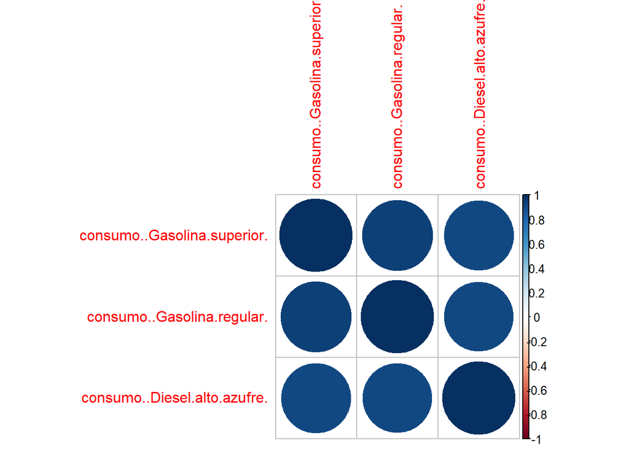

### 1. ¿Cuáles son los 10 meses que más consumo registraron de diesel?

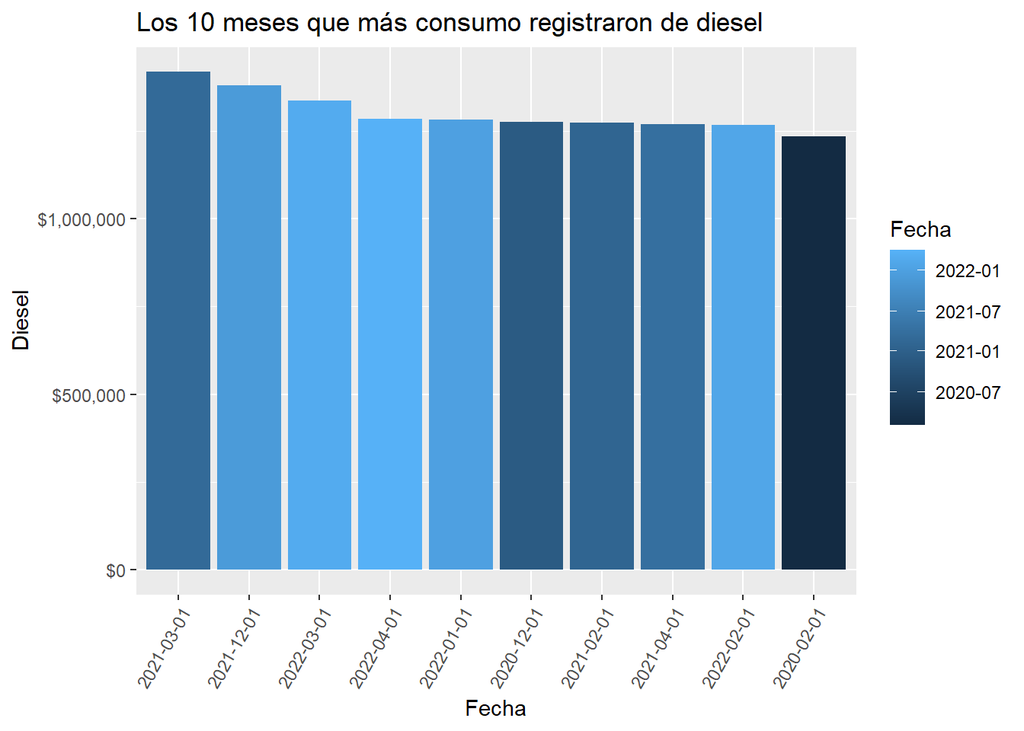

```r
pregunta1
```

El mes con mayor consumo de diesel fue en marzo de 2021.

### 2. ¿Cuáles son los 10 meses que más consumo registraron de gasolina superior?

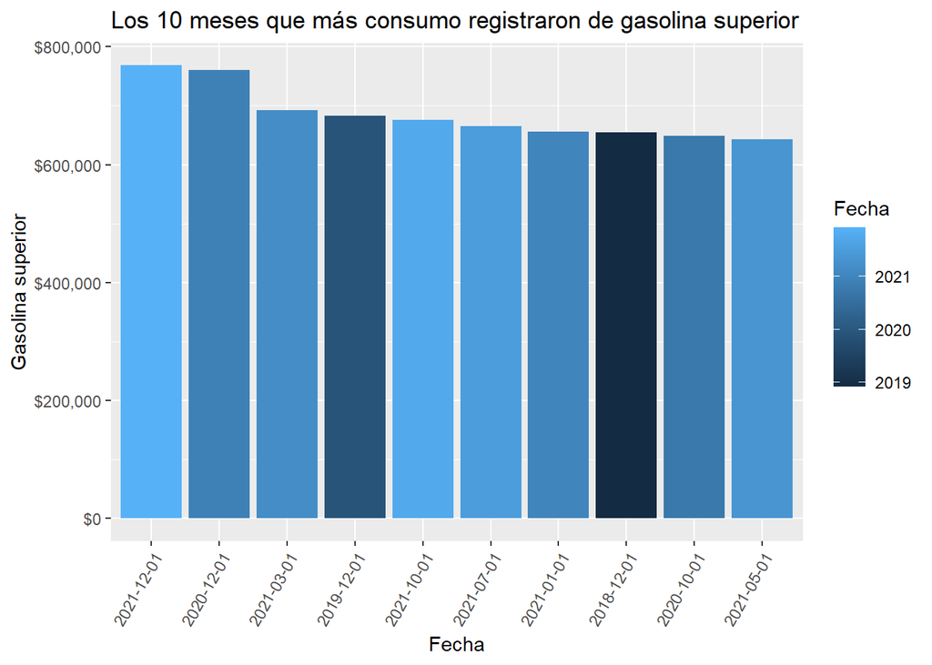

```r
pregunta2
```

El mes con mayor consumo de gasolina superior fue en diciembre de 2021.

### 3. ¿Cuáles son los 10 meses que más consumo registraron de gasolina regular?

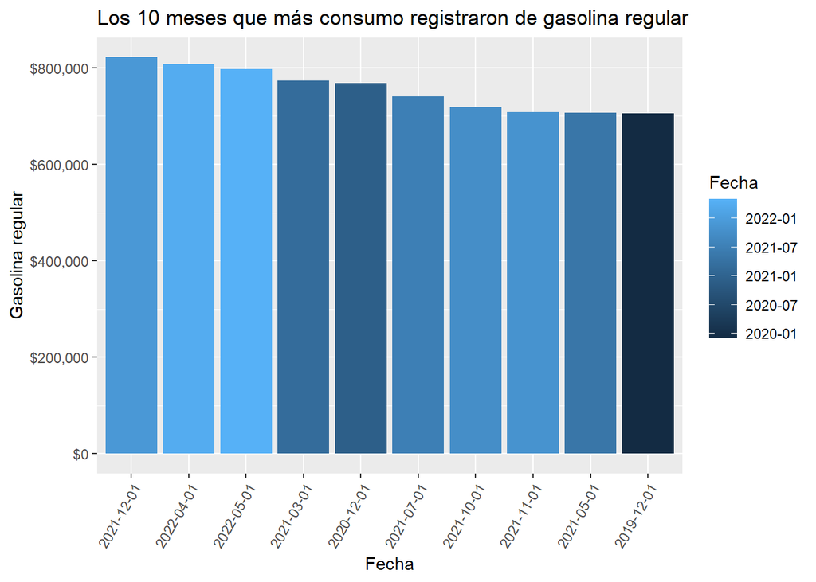

```r
pregunta3
```

El mes con mayor consumo de gasolina regular fue en diciembre de 2021.

### 4. ¿Cuáles son los 10 meses que menos consumo registraron de diesel?

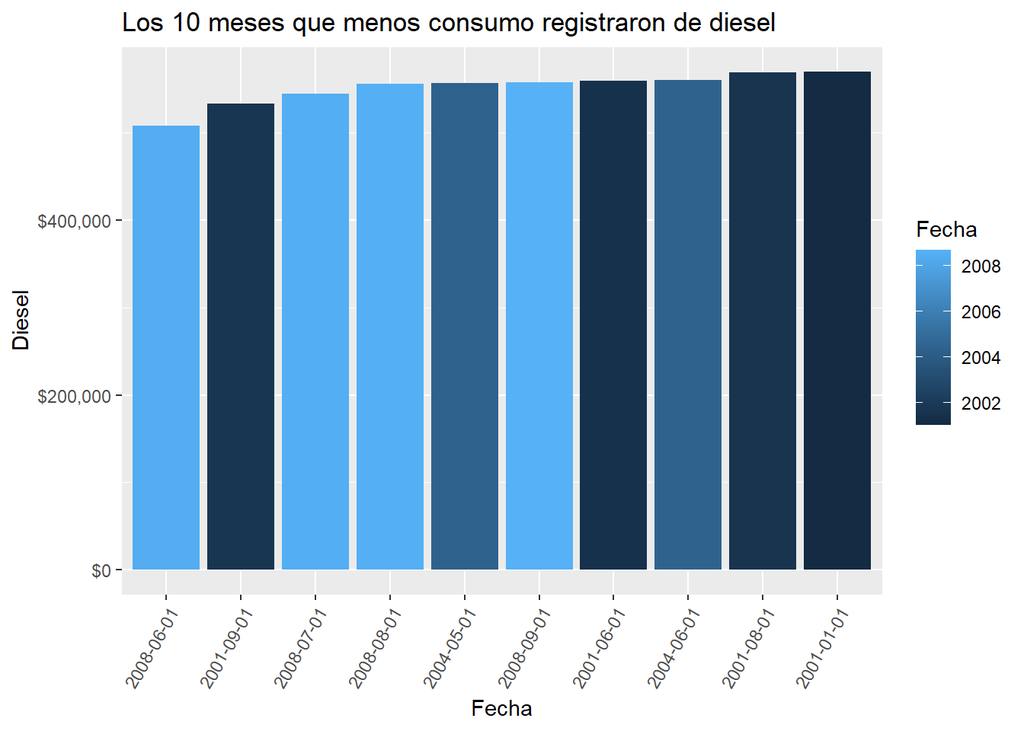

```r
pregunta4
```

El mes con menos consumo de diesel fue en junio de 2008.

### 5. ¿Cuáles son los 10 meses que menos consumo registraron de gasolina superior?

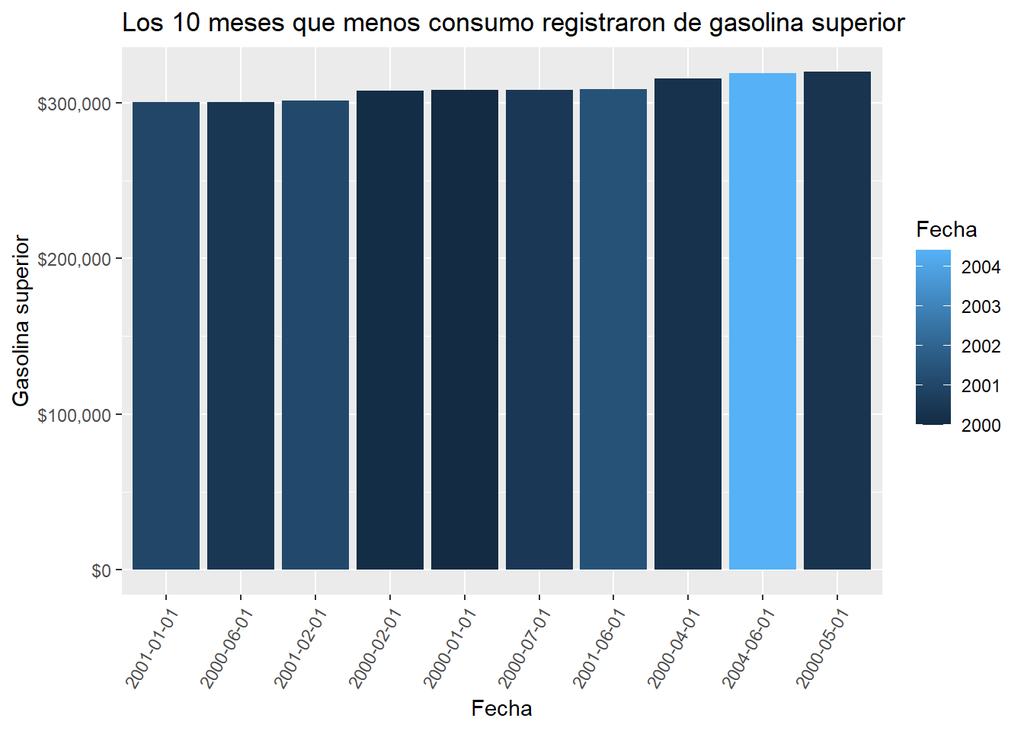

```r
pregunta5
```

El mes con menos consumo de gasolina super fue en enero de 2001.

### 6. ¿Cuáles son los 10 meses que menos consumo registraron de gasolina regular?

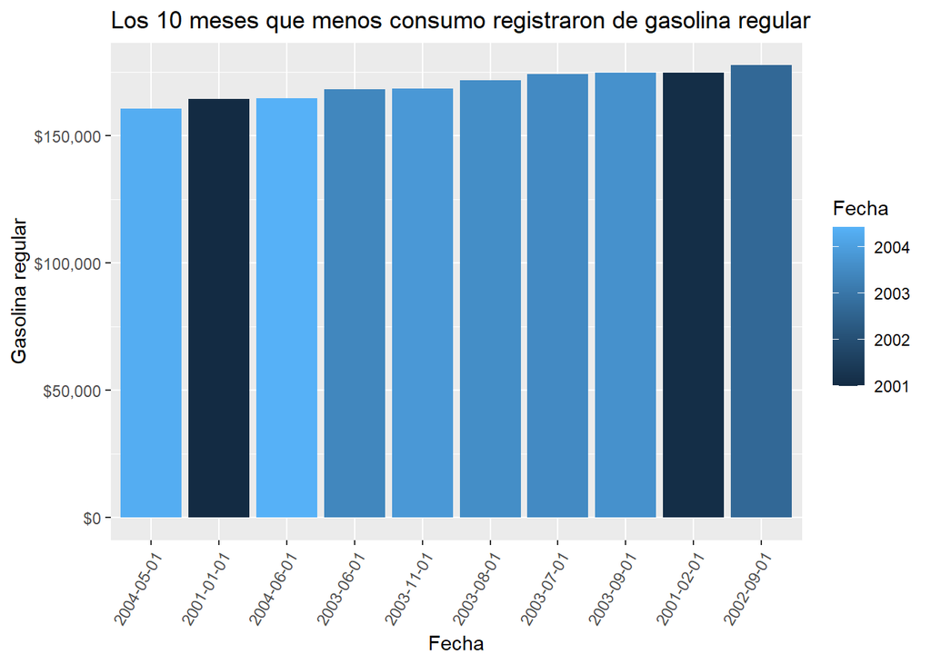

```r
pregunta6
```

El mes con menos consumo de gasolina regular fue en mayo de 2004.

## Series de Tiempo

### Serie de tiempo del combustible diesel

En este laboratorio usaremos la construcción de modelos ARIMA el cual consta de 4 pasos: 1. Indentificación 2. Estimación 3. Validación 4. Predicción

#### Identificación

```r
diesel_ts<-ts(dieselc$`Diesel alto azufre`, start = c(2001,1),frequency = 12)
start(diesel_ts)
```

```
## [1] 2001    1
```

```r
end(diesel_ts)
```

```
## [1] 2023    5
```

```r
frequency(diesel_ts)
```

```
## [1] 12
```

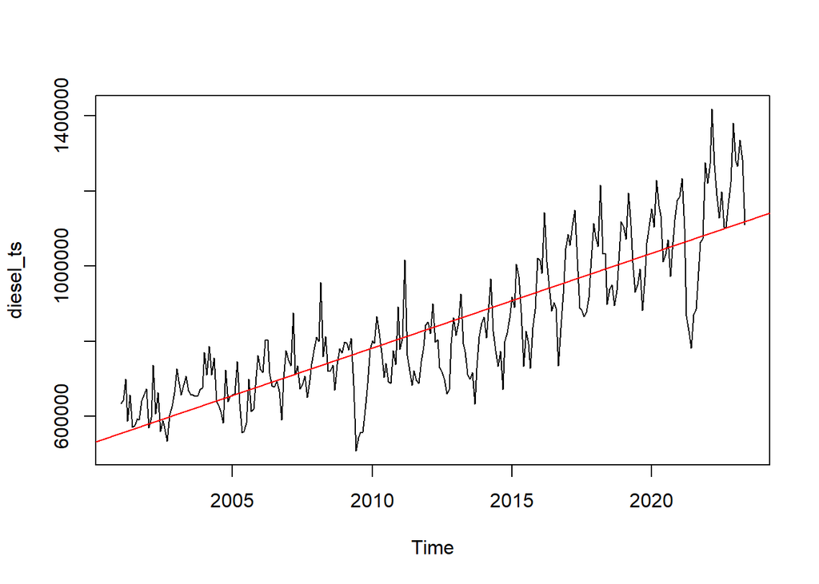

```r
plot(diesel_ts)
abline(reg=lm(diesel_ts~time(diesel_ts)), col=c("red"))
```

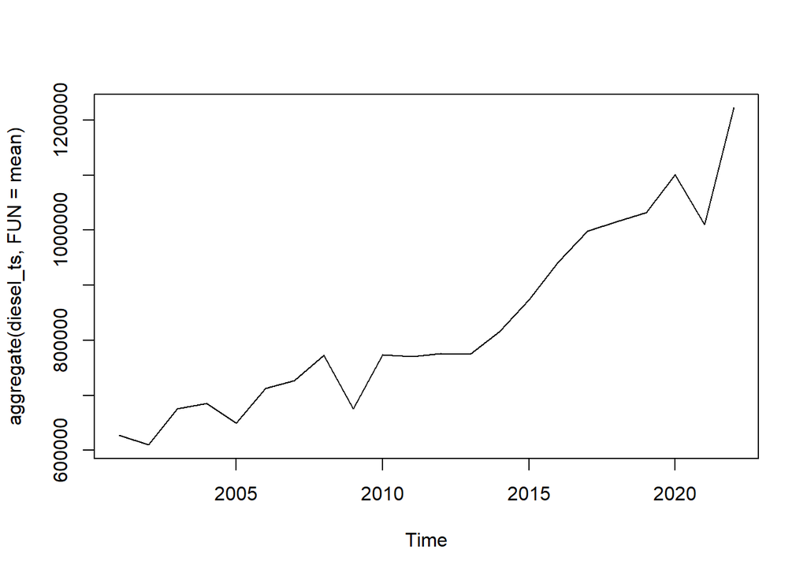

```r
plot(aggregate(diesel_ts,FUN=mean))
```

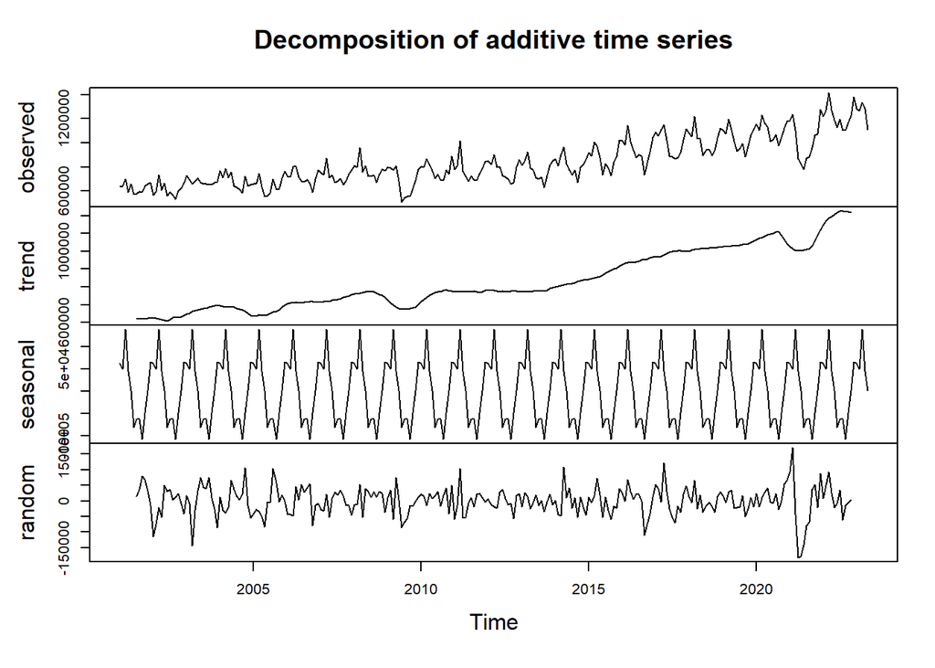

```r
dec.Diesel<-decompose(diesel_ts)
plot(dec.Diesel)
```

En estas gráficas se afirma la tendencia a aumentar del consumo de diesel y que no es estacionaria en varianza.

#### Estimación

Como no es estacionaria en varianza se hizo una transformación logarítmica para hacerla estacionaria en varianza. Se realizó con la serie de entrenamiento que es la que nos ayudará a predecir.

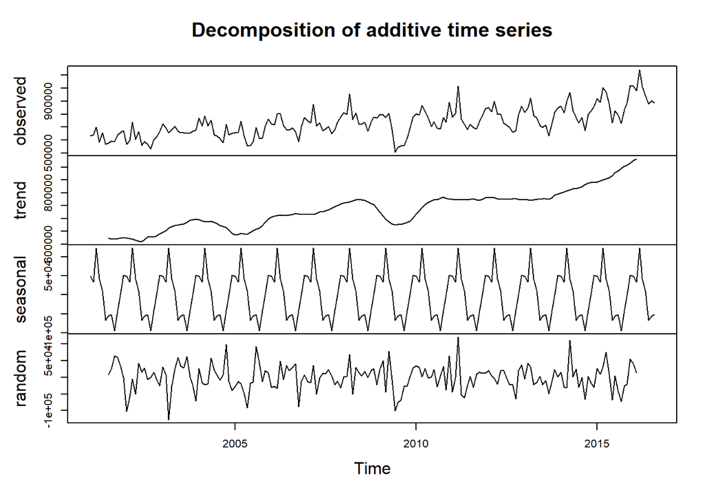

```r
train<-head(diesel_ts, round(length(diesel_ts) * 0.7))
h<-length(diesel_ts) - length(train)
test<-tail(diesel_ts, h)

#Aplicaremos una transformación logarítmica
logDiesel<-log(train)
plot(decompose(train))
```

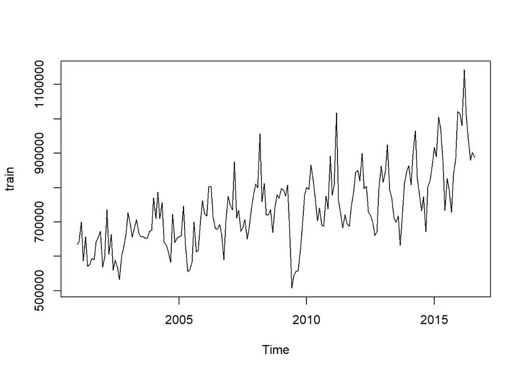

```r
plot(train)
```

Aparentemente ahora la serie es estacionaria en varianza. Ahora se debe verificar si es estacionaria en media, si tiene raices unitarias podemos decir que no es estacionaria en media y hay que aplicar procesos de diferenciación.

```r
#Para saber si hay raíces unitarias
adfTest(train)
```

```
##
## Title:
##  Augmented Dickey-Fuller Test
##
## Test Results:
##   PARAMETER:
##     Lag Order: 1
##   STATISTIC:
##     Dickey-Fuller: -0.1845
##   P VALUE:
##     0.5562
##
## Description:
##  Mon Aug 08 23:41:16 2022 by user: xavih
```

```r
unitrootTest(train)
```

```
##
## Title:
##  Augmented Dickey-Fuller Test
##
## Test Results:
##   PARAMETER:
##     Lag Order: 1
##   STATISTIC:
##     DF: -0.1845
##   P VALUE:
##     t: 0.6185
##     n: 0.6377
##
## Description:
##  Mon Aug 08 23:41:16 2022 by user: xavih
```

Se observa que el valor de P es mayor a 0.05 por lo que la hipótesis nula no se rechaza, esto quiere decir que la serie no es estacionaria. Ahora veamos con diferenciación.

```r
adfTest(diff(train))
```

```
##
## Title:
##  Augmented Dickey-Fuller Test
##
## Test Results:
##   PARAMETER:
##     Lag Order: 1
##   STATISTIC:
##     Dickey-Fuller: -11.2634
##   P VALUE:
##     0.01
##
## Description:
##  Mon Aug 08 23:41:16 2022 by user: xavih
```

```r
unitrootTest(diff(train))
```

```
##
## Title:
##  Augmented Dickey-Fuller Test
##
## Test Results:
##   PARAMETER:
##     Lag Order: 1
##   STATISTIC:
##     DF: -11.2634
##   P VALUE:
##     t: < 2.2e-16
##     n: 0.01844
##
## Description:
##  Mon Aug 08 23:41:16 2022 by user: xavih
```

Ahora el valor de P sí está por debajo de 0.05 y la hipótesis nula se rechaza diciendo que la serie es estacionaria. Ahora trataremos de identificar los parámetros p y q usando los gráficos de autocorrelación y autocorrelación parcial.

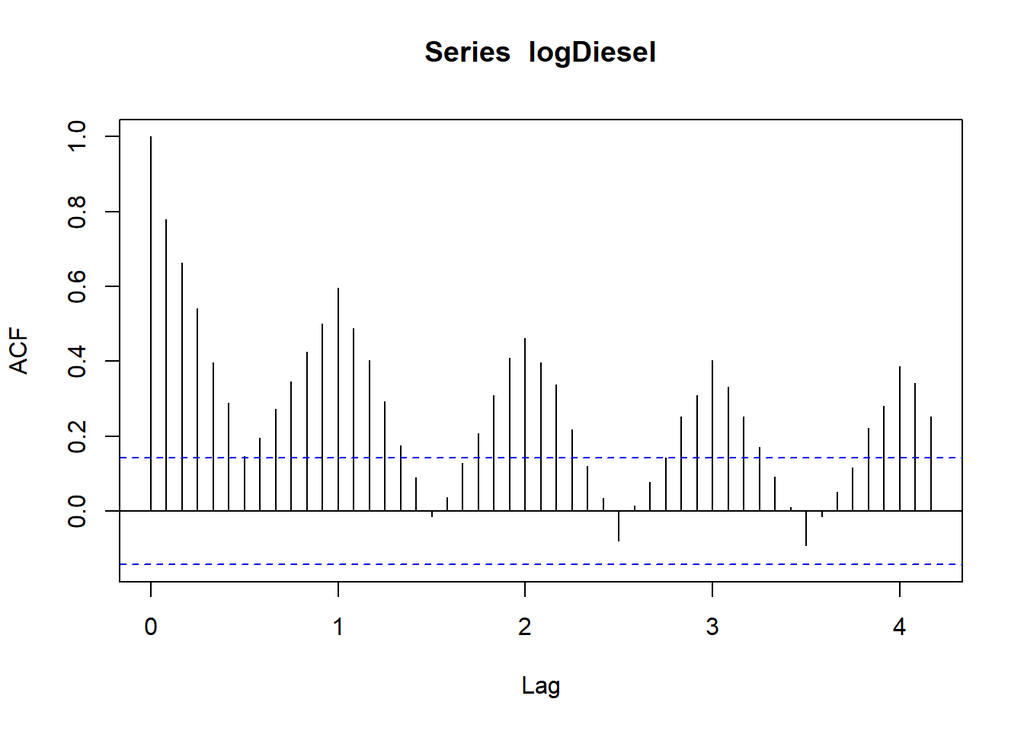

```r
#Gráfico de autocorrelación
acf(logDiesel,50)
```

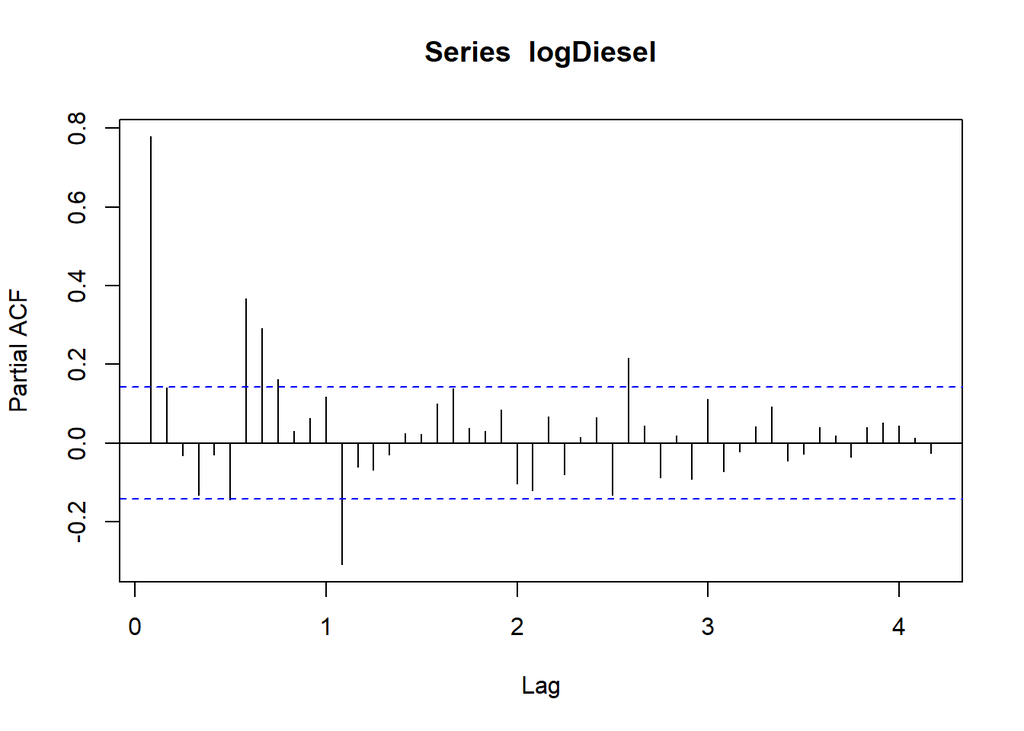

```r
pacf(logDiesel,50)
```

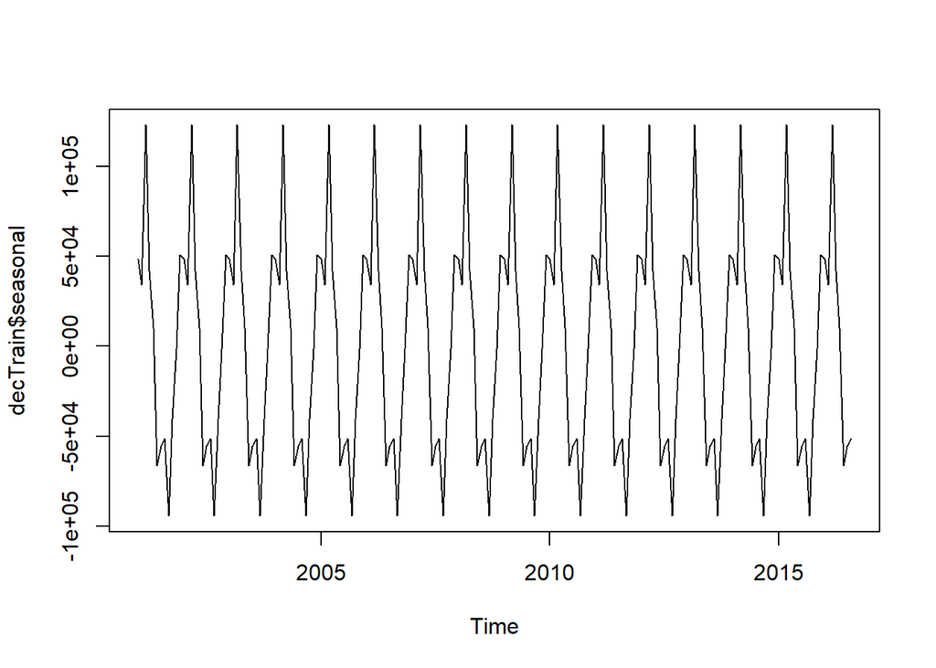

```r
decTrain<-decompose(train)
plot(decTrain$seasonal)
```

Al parecer sí existe estacionalidad en la serie. Para tener una idea de los parámetros estacionales veremos las funciones de autocorrelación y autocorrelación parcial con 36 resagos para ver en qué momentos son los picos estacionales, se usará la serie estacionarizada.

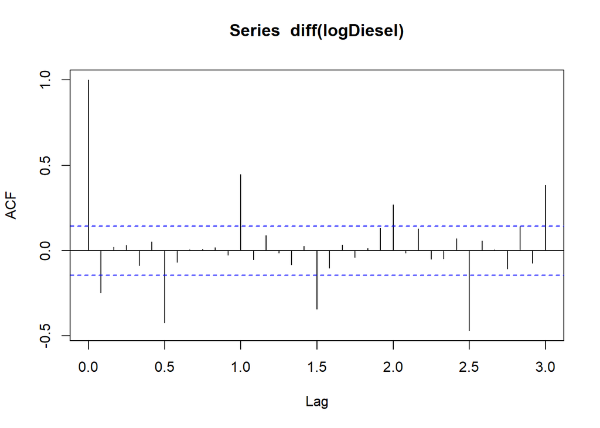

```r
acf(diff(logDiesel),36)
```

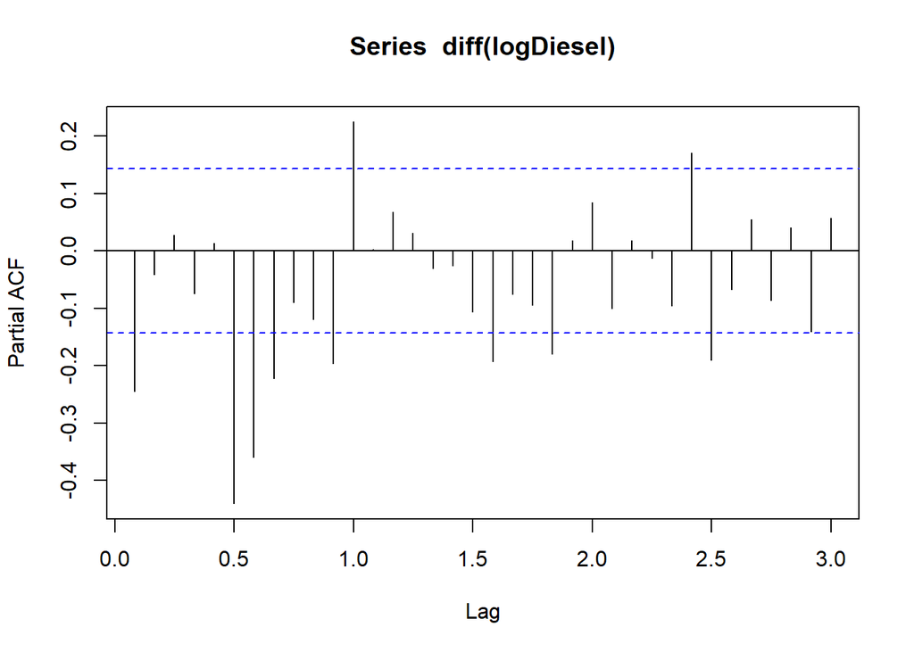

```r
pacf(diff(logDiesel),36)
```

```r
fitArima<-arima(logDiesel,order=c(2,1,2),seasonal = c(1,1,0))
fitAutoArima<-auto.arima(train)
```

#### Validación

```r
coeftest(fitArima)
```

```
##
## z test of coefficients:
##
##       Estimate Std. Error z value  Pr(>|z|)
## ar1  -0.675134   0.342613 -1.9705   0.04878 *
## ar2  -0.128283   0.138032 -0.9294   0.35270
## ma1   0.090229   0.342360  0.2635   0.79213
## ma2  -0.351093   0.259002 -1.3556   0.17524
## sar1 -0.458071   0.068246 -6.7121 1.919e-11 ***
## ---
## Signif. codes:  0 '***' 0.001 '**' 0.01 '*' 0.05 '.' 0.1 ' ' 1
```

```r
coeftest(fitAutoArima)
```

```
##
## z test of coefficients:
##
##         Estimate Std. Error z value  Pr(>|z|)
## ar1      0.13208    0.43515  0.3035   0.76148
## ar2      0.24422    0.20294  1.2034   0.22881
## ar3      0.25964    0.10369  2.5040   0.01228 *
## ma1      0.24814    0.45854  0.5411   0.58841
## sar1    -0.52088    0.42422 -1.2279   0.21949
## sma1    -0.25468    0.41276 -0.6170   0.53722
## sma2    -0.47963    0.33011 -1.4529   0.14624
## drift 1504.70639  266.77040  5.6405 1.696e-08 ***
## ---
## Signif. codes:  0 '***' 0.001 '**' 0.01 '*' 0.05 '.' 0.1 ' ' 1
```

##### Analisis de residuales

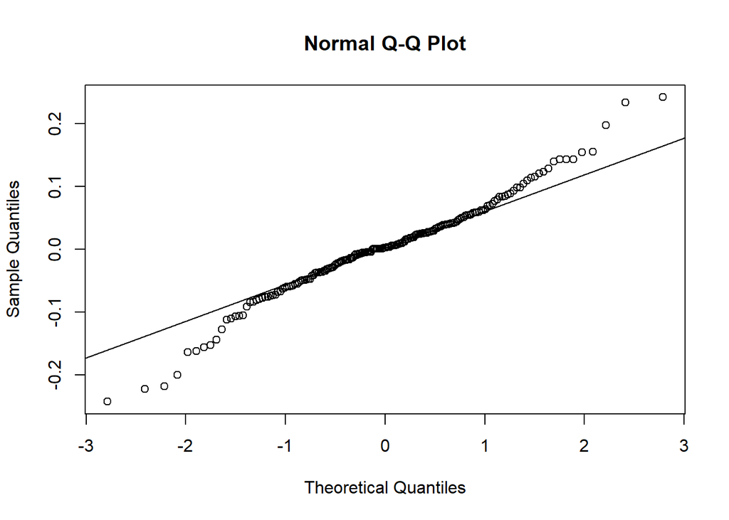

```r
qqnorm(fitArima$residuals)
qqline(fitArima$residuals)
```

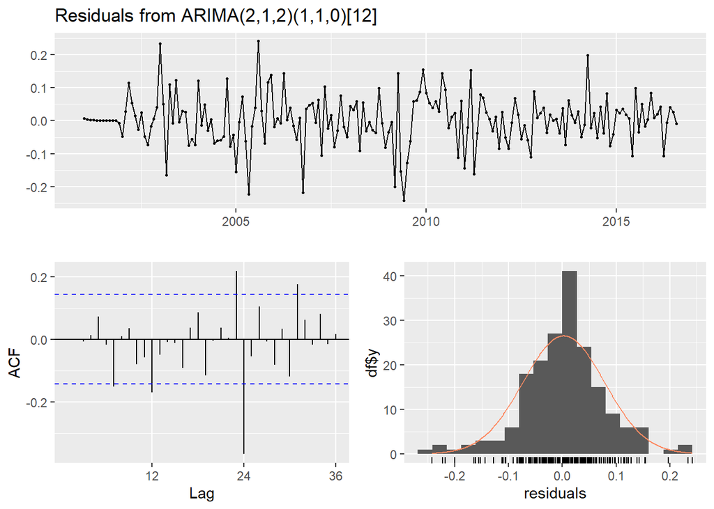

```
##
##  Ljung-Box test
##
## data:  Residuals from ARIMA(2,1,2)(1,1,0)[12]
## Q* = 60.264, df = 19, p-value = 3.515e-06
##
## Model df: 5.   Total lags used: 24
```

```r
checkresiduals(fitArima)
```

Según el test de Ljung-Box el valor de P es menor a 0.05 por lo que se rechaza la hipótesis nula, lo que significa que los residuos no se distribuyen de forma independiente, exhiben correlación serial.

Ahora analizamos los residuos del modelo generado de forma automática por R.

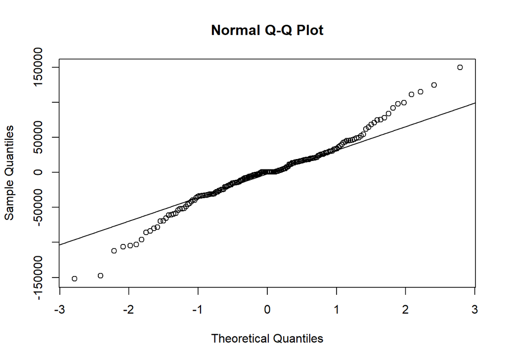

```r
qqnorm(fitAutoArima$residuals)
qqline(fitAutoArima$residuals)
```

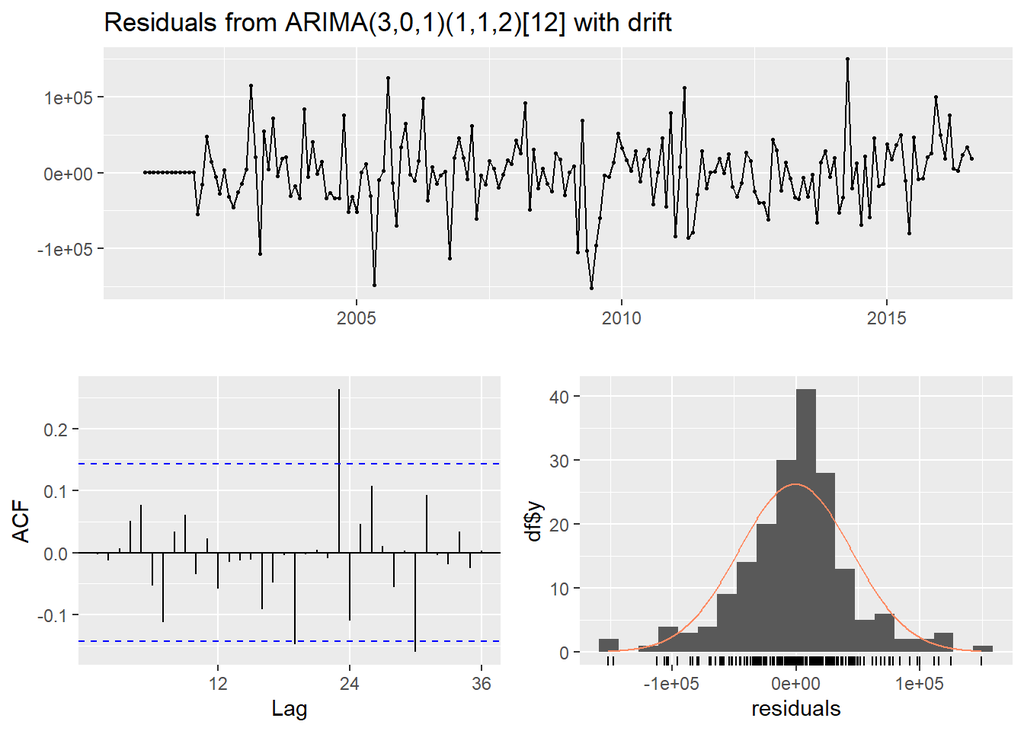

```
##
##  Ljung-Box test
##
## data:  Residuals from ARIMA(3,0,1)(1,1,2)[12] with drift
## Q* = 31.355, df = 17, p-value = 0.01807
##
## Model df: 7.   Total lags used: 24
```

```r
checkresiduals(fitAutoArima)
```

Se observa un caso bastante similar.

#### Predicción

```r
# Hacer el modelo
auto.arima(diesel_ts)
```

```
## Series: diesel_ts
## ARIMA(3,0,1)(1,1,2)[12] with drift
##
## Coefficients:
##          ar1     ar2     ar3     ma1     sar1     sma1     sma2      drift
##       0.0080  0.4241  0.2493  0.5221  -0.6274  -0.1681  -0.5414  2102.6840
## s.e.  0.2894  0.1829  0.0712  0.2984   0.4041   0.3972   0.3217   292.5522
##
## sigma^2 = 2.756e+09:  log likelihood = -3160.79
## AIC=6339.58   AICc=6340.3   BIC=6371.52
```

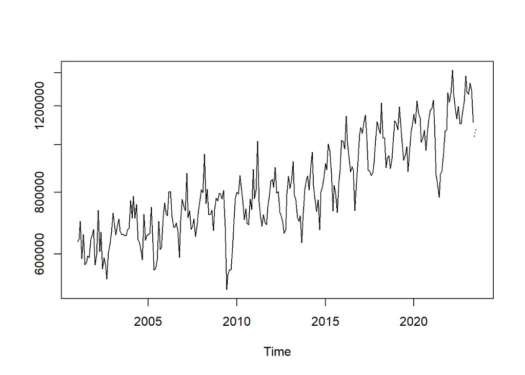

```r
fit<-arima(log(diesel_ts), c(0, 1, 1),seasonal = list(order = c(0, 1, 1), period = 12))
pred<-predict(fit, n.ahead = 3)
ts.plot(diesel_ts,2.718^pred$pred, log = "y", lty = c(1,3))
```

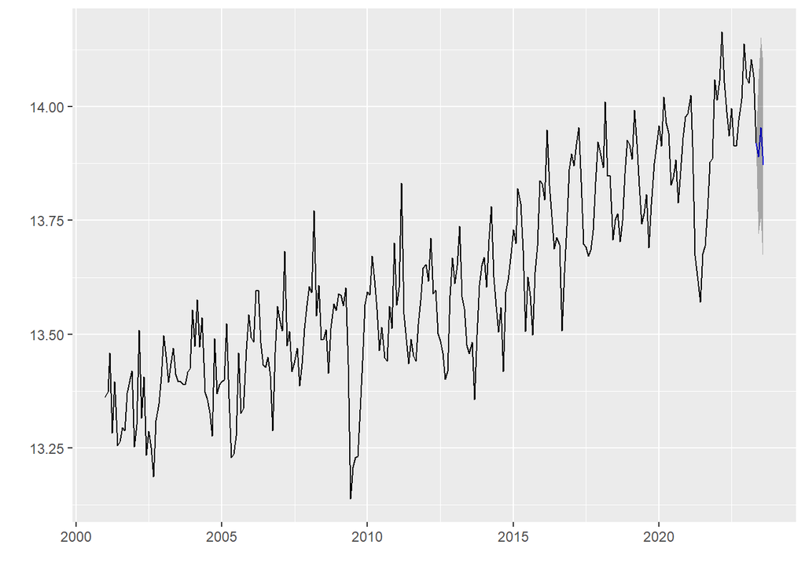

```r
fit2<-arima(log(diesel_ts), c(2, 1, 1),seasonal = list(order = c(0, 1, 0), period = 12))
forecastAP1<-forecast(fit2, level = c(95), h = 3)
autoplot(forecastAP1)
```

```r
diesel_ts2018<-ts( diesel$`Diesel alto azufre`, start = c(2001,1), end=c(2020,12) ,frequency = 12)
auto.arima(diesel_ts2018)
```

```
## Series: diesel_ts2018
## ARIMA(3,0,2)(1,1,2)[12] with drift
##
## Coefficients:
##          ar1     ar2     ar3     ma1      ma2     sar1     sma1     sma2
##       0.1796  0.4687  0.1684  0.1924  -0.2268  -0.7171  -0.0374  -0.5752
## s.e.  0.3024  0.3047  0.1236  0.3048   0.2327   0.4806   0.4696   0.3594
##           drift
##       2018.2888
## s.e.   356.1529
##
## sigma^2 = 2.177e+09:  log likelihood = -2775.69
## AIC=5571.38   AICc=5572.4   BIC=5605.67
```

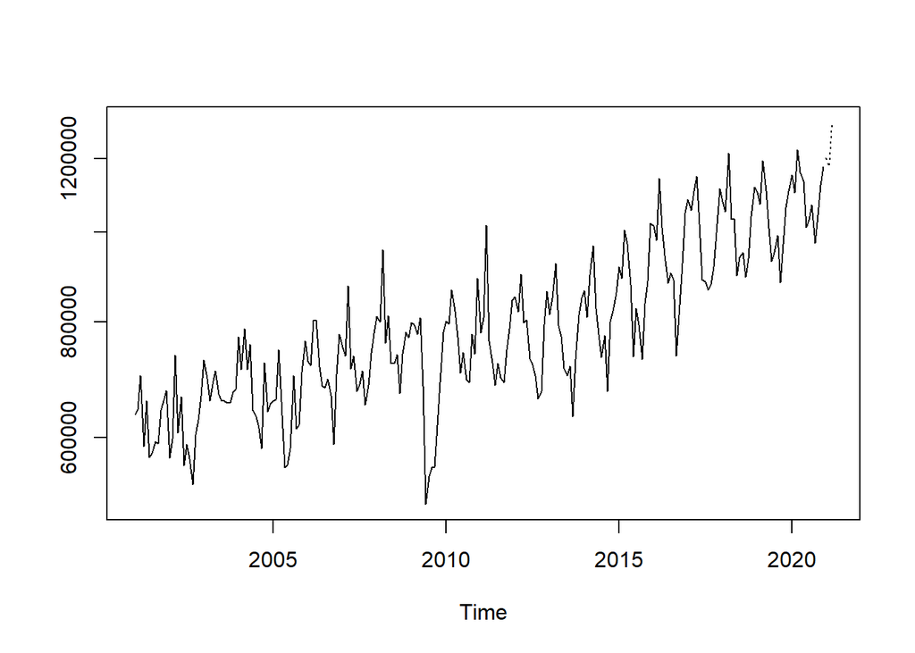

```r
fit<-arima(log(diesel_ts2018), c(0, 1, 1),seasonal = list(order = c(0, 1, 1), period = 12))
pred<-predict(fit, n.ahead = 3)
ts.plot(diesel_ts2018,2.718^pred$pred, log = "y", lty = c(1,3))
```

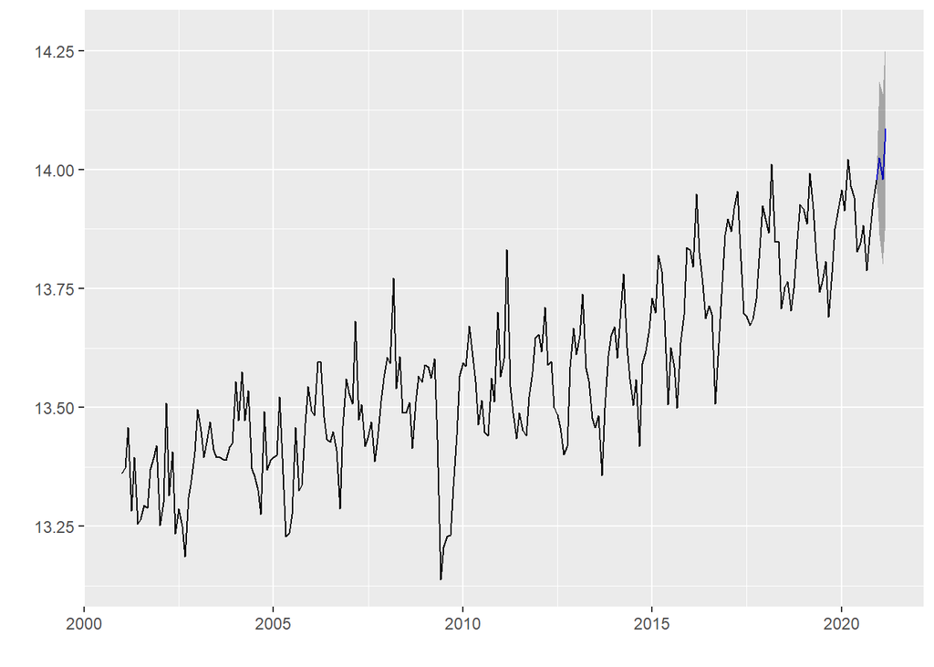

```r
fit2<-arima(log(diesel_ts2018), c(2, 1, 1),seasonal = list(order = c(0, 1, 0), period = 12))
forecastAP<-forecast(fit2, level = c(95), h = 3)
autoplot(forecastAP)
```

Se concluye que la predicción hecha es buena, ya que las gráficas son muy similares a las gráficas generadas anteriormente.

#### Prophet

```r
df<-data.frame(ds=as.Date(as.yearmon(time(train))),y=as.matrix(train) )
testdf<-data.frame(ds=as.Date(as.yearmon(time(test))),y=as.matrix(test) )
head(df)
```

```
##           ds        y
## 1 2001-01-01 634667.1
## 2 2001-02-01 642380.7
## 3 2001-03-01 699807.2
## 4 2001-04-01 586804.0
## 5 2001-05-01 656948.2
## 6 2001-06-01 570919.9
```

```r
fitProphet<-prophet(df,yearly.seasonality = T,weekly.seasonality = T)
```

```
## Disabling daily seasonality. Run prophet with daily.seasonality=TRUE to override this.
```

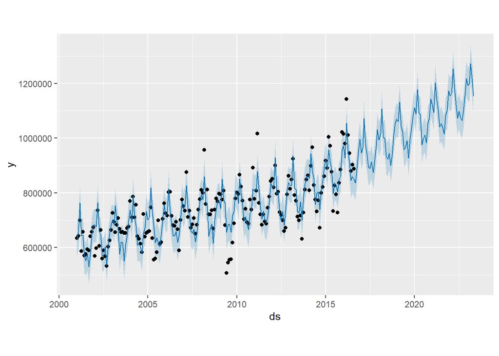

```r
future<-make_future_dataframe(fitProphet,periods = h,freq = "month", include_history = T)
p<-predict(fitProphet,future)
p<-p[,c("ds","yhat","yhat_lower","yhat_upper")]
plot(fitProphet,p)
```

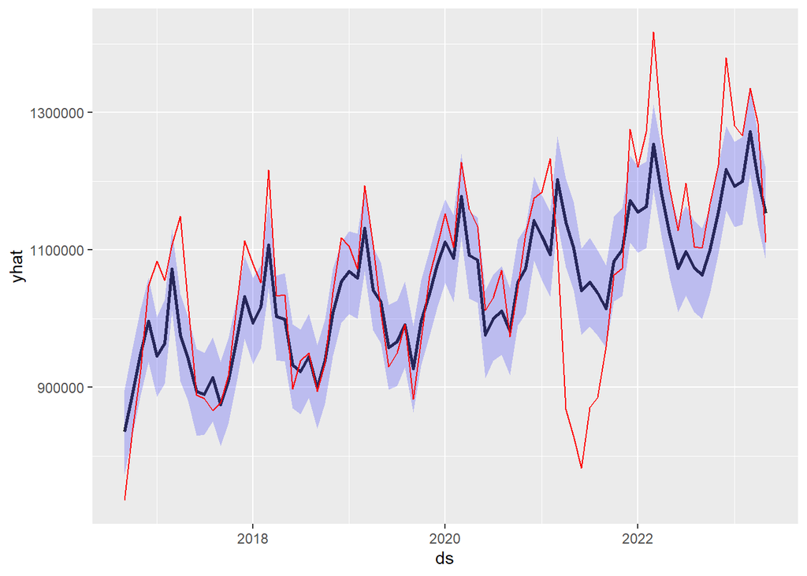

```r
pred<-tail(p,h)
pred$y<-testdf$y

ggplot(pred, aes(x=ds, y=yhat)) +
   geom_line(size=1, alpha=0.8) +
   geom_ribbon(aes(ymin=yhat_lower, ymax=yhat_upper), fill="blue", alpha=0.2) +
   geom_line(data=pred, aes(x=ds, y=y),color="red")
```